# Analyse des accidents de la route — Insights clés (BAAC 2024)

## Objectif

Présenter les principaux enseignements issus de l’analyse des accidents corporels de la circulation en France à partir des données BAAC 2024, dans une logique d’aide à la décision et de prévention.

```
Project root: C:\Users\Hannae\Documents\Projets\accidents-france-baac
```

```
(70248, 35) (125187, 3)
```

## Insight 1 — Concentration des accidents aux heures de pointe

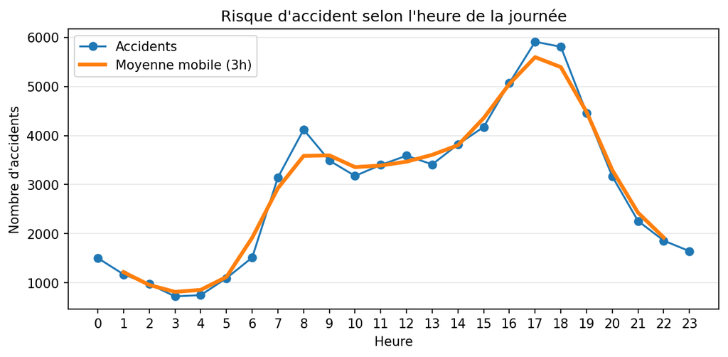

Les accidents sont majoritairement concentrés aux heures de pointe, notamment le matin et en fin de journée. Cette répartition suggère un lien fort avec les déplacements domicile–travail.

## Insight 2 — Répartition hebdomadaire des accidents

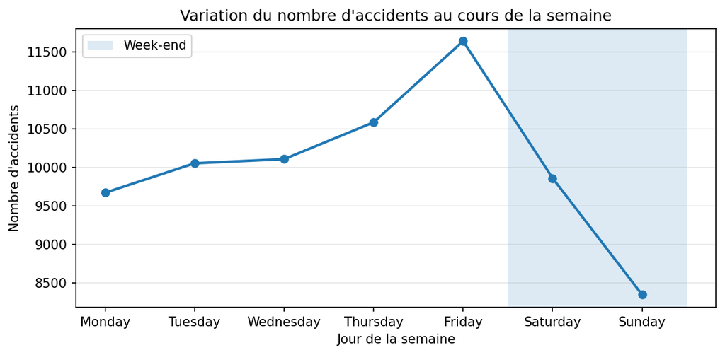

Les accidents sont plus fréquents en semaine, avec une baisse notable le dimanche, confirmant l’impact des déplacements professionnels sur la sinistralité routière.

## Insight 3 — Gravité des accidents impliquant les usagers

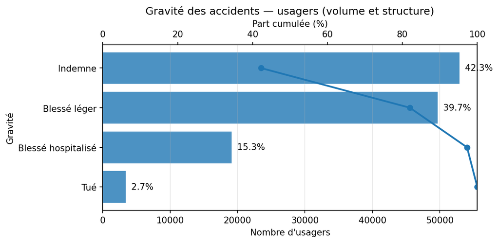

La majorité des usagers impliqués dans les accidents sont indemnes ou légèrement blessés. Les accidents mortels restent minoritaires, mais représentent un enjeu majeur en termes de prévention.

## Insight 4 — Périodes horaires à risque élevé

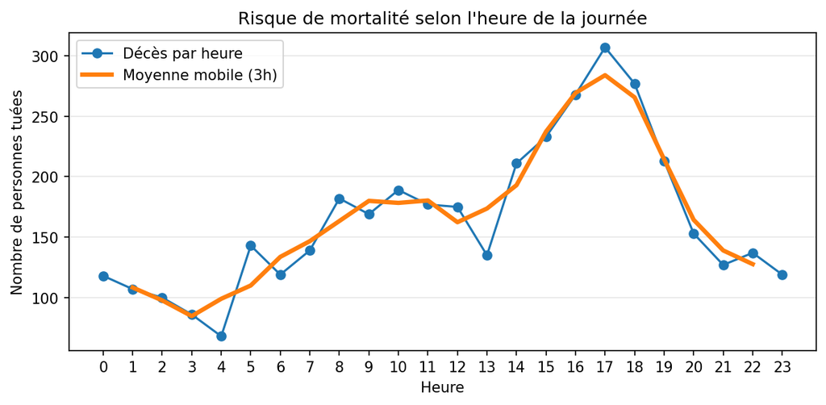

Le croisement entre l’heure de l’accident et la gravité met en évidence des périodes à risque élevé, durant lesquelles les accidents mortels sont plus fréquents.

Ces créneaux pourraient constituer des cibles prioritaires pour des actions de prévention renforcées.

## Insight 5 — Top Départements

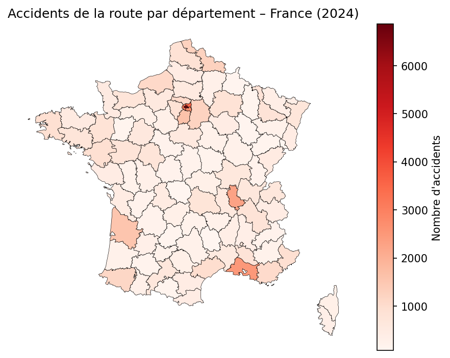

Les départements les plus peuplés concentrent logiquement le plus grand nombre d’accidents. Cette analyse en volume brut met en évidence des zones prioritaires en termes d’exposition, mais nécessite une normalisation par la population ou le trafic pour évaluer la dangerosité relative.